# Statystyczna Analiza Danych

Ewelina Nieć, Julia Nikiel

19.10.2022

# Projekt

## Opis i wstępna analiza wykorzystywanych danych

Celem projektu jest przedstwaienie rankingu aut elektrycznych wykorzystując metody porządkowania liniowego oraz przeprowadzenie analizy skupień.

- Cena - [zł] cena podstawowego pakietu na dzień 05.10.2022r (dane zaczerpnięte z oficjalnych stron producentów) - destymulanta
- Km - konie mechaniczne - stymulanta
- Rozstaw_osi - [cm] - większy rozstaw osi wpływa na wyższy poziom bezpieczeństwa, jednak krótszy rozstaw poprawia zwrotność, dlatego zmienna ta jest nominantą na poziomie 250
- Pojemnosc_bagaznika - [l] maksymalna pojemność bagażnika (przy złożonych tylnich siedzeniach) - najbardziej optymalną wielkością bagażnika jest 1183l
- Predkosc_maksymalna - [km/h] - stymulanta
- Przyspieszenie - [s] od 0km/h do 100km/h - destymulanta
- Zasieg - [km] odległość jakią auto przejedzie na jednym ładowaniu - stymulanta
- Dostepnosc - liczba ogłoszeń na platformie OtoMoto na dzień 05.10.2022 - stymulanta

Wczytujemy dane:

```r
Auta <- read_excel("Auta.xlsx")
knitr::kable((Auta), "markdown")
```

| Marka | Model | Cena | Km | Rozstaw_osi | Pojemnosc_bagaznika | Predkosc_maksymalna | Przyspieszenie | Zasieg | Dostepnosc |
| --- | --- | --- | --- | --- | --- | --- | --- | --- | --- |
| DS3 | Crossback E-Tense | 186900 | 136 | 256.0 | 1050 | 150 | 9.1 | 341 | 15 |
| Hyundai | Kona Electric | 175900 | 204 | 260.0 | 1114 | 167 | 7.9 | 484 | 12 |
| Kia | e-Niro 64 kWh | 191900 | 204 | 270.0 | 1405 | 167 | 7.8 | 455 | 18 |
| Mazda | MX-30 | 153900 | 145 | 266.0 | 1171 | 145 | 9.7 | 200 | 15 |
| Nissan | Leaf 62 kWh | 202900 | 217 | 270.0 | 1161 | 157 | 6.9 | 378 | 72 |
| Peugeot | e-2008 | 104700 | 136 | 261.0 | 1467 | 150 | 9.0 | 320 | 9 |
| Volkswagen | ID.3 | 191490 | 204 | 277.0 | 1267 | 160 | 7.3 | 411 | 26 |
| Volkswagen | ID.BuzzPro | 201700 | 204 | 299.0 | 2205 | 145 | 10.2 | 419 | 5 |
| Ford | Mustang Mach-E GT | 276500 | 487 | 299.0 | 1420 | 200 | 3.7 | 490 | 26 |
| Porsche | Tycan 4S Sport Turismo | 621782 | 490 | 290.0 | 407 | 250 | 4.0 | 563 | 12 |
| Mercedes-Benz | EQV | 335175 | 204 | 320.0 | 4630 | 160 | 12.1 | 356 | 30 |
| Opel | Mokka-e | 166400 | 136 | 256.0 | 1060 | 150 | 9.0 | 324 | 8 |
| Toyota | Proace Electric Life | 155600 | 136 | 327.0 | 5100 | 130 | 12.1 | 330 | 2 |
| Skoda | Enyaq iV | 210150 | 204 | 277.0 | 585 | 160 | 8.5 | 534 | 33 |
| Audi | Q4 e-tron | 248130 | 299 | 276.4 | 1490 | 180 | 6.2 | 516 | 19 |
| Audi | e-tron GT quattro | 463630 | 476 | 290.0 | 1725 | 245 | 4.2 | 488 | 37 |
| BMW | iX xDrive40 | 479950 | 326 | 300.0 | 1750 | 200 | 6.1 | 425 | 37 |
| BMW | i4 M50 | 435800 | 544 | 285.6 | 1290 | 225 | 3.9 | 502 | 10 |
| Mercedes-Benz | EQS 350 | 453300 | 292 | 321.0 | 1770 | 210 | 6.6 | 712 | 25 |
| Tesla | S | 475990 | 670 | 296.0 | 793 | 250 | 3.2 | 652 | 41 |
| Kia | e-Soul | 149990 | 136 | 260.0 | 1339 | 156 | 9.7 | 276 | 7 |
| Opel | Combo-e Life | 188750 | 136 | 279.0 | 2126 | 175 | 11.5 | 280 | 3 |
| BMW | i7 xDrive60 | 650000 | 544 | 321.5 | 500 | 240 | 4.7 | 625 | 1 |
| Smart | EQ fortwo cabrio | 113200 | 82 | 187.3 | 190 | 130 | 12.7 | 132 | 0 |

### Podstawowe statystyki:

```r
knitr::kable(summary(Auta[,c(-1,-2)]), "markdown")
```

|  | Cena | Km | Rozstaw_osi | Pojemnosc_bagaznika | Predkosc_maksymalna | Przyspieszenie | Zasieg | Dostepnosc |
| --- | --- | --- | --- | --- | --- | --- | --- | --- |
|  | Min. :104700 | Min. : 82.0 | Min. :187.3 | Min. : 190 | Min. :130.0 | Min. : 3.200 | Min. :132.0 | Min. : 0.00 |
|  | 1st Qu.:173525 | 1st Qu.:136.0 | 1st Qu.:264.8 | 1st Qu.:1058 | 1st Qu.:150.0 | 1st Qu.: 5.750 | 1st Qu.:328.5 | 1st Qu.: 7.75 |
|  | Median :202300 | Median :204.0 | Median :278.0 | Median :1314 | Median :163.5 | Median : 7.850 | Median :422.0 | Median :15.00 |
|  | Mean :284739 | Mean :275.5 | Mean :281.0 | Mean :1542 | Mean :179.2 | Mean : 7.754 | Mean :425.5 | Mean :19.29 |
|  | 3rd Qu.:440175 | 3rd Qu.:363.5 | 3rd Qu.:299.0 | 3rd Qu.:1731 | 3rd Qu.:202.5 | 3rd Qu.: 9.700 | 3rd Qu.:505.5 | 3rd Qu.:27.00 |
|  | Max. :650000 | Max. :670.0 | Max. :327.0 | Max. :5100 | Max. :250.0 | Max. :12.700 | Max. :712.0 | Max. :72.00 |

Wizualizacja:

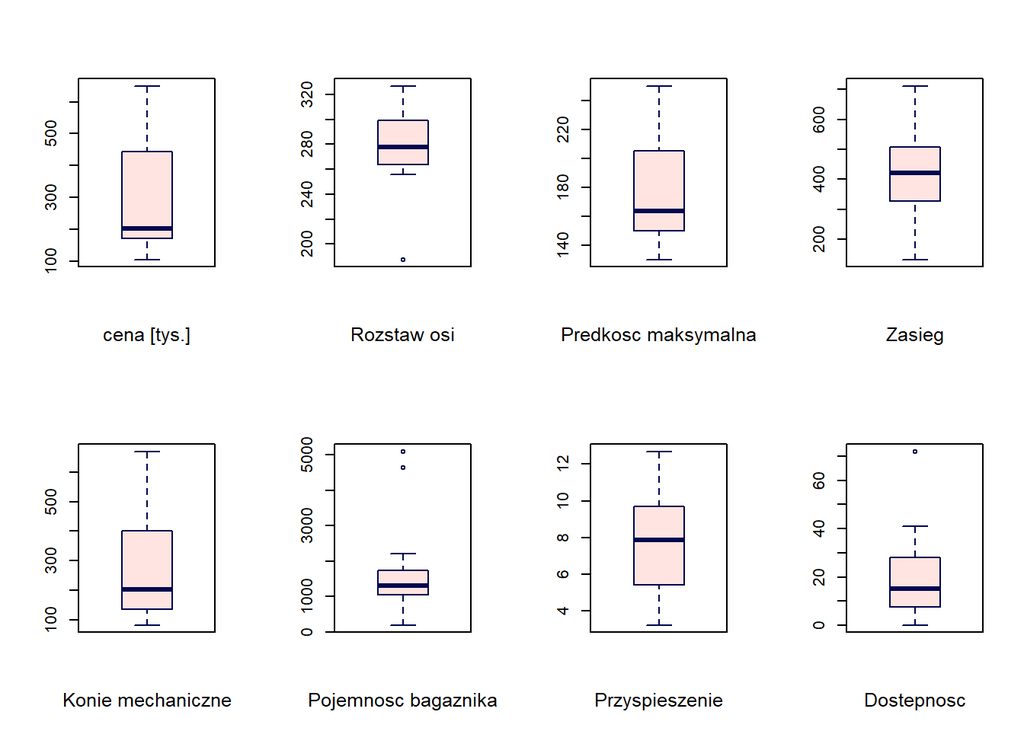

```r
par(mfcol = c(2,4))
boxplot(Auta[,3]/1000,xlab="cena [tys.]",col="#FFE4E1",border = "#00084F", cex.lab=1.2)
boxplot(Auta[,4],xlab="Konie mechaniczne",col="#FFE4E1",border = "#00084F", cex.lab=1.2)
boxplot(Auta[,5],xlab="Rozstaw osi",col="#FFE4E1",border = "#00084F", cex.lab=1.2)
boxplot(Auta[,6],xlab="Pojemnosc bagaznika",col="#FFE4E1",border = "#00084F", cex.lab=1.2)
boxplot(Auta[,7],xlab="Predkosc maksymalna",col="#FFE4E1",border = "#00084F", cex.lab=1.2)
boxplot(Auta[,8],xlab="Przyspieszenie",col="#FFE4E1",border = "#00084F", cex.lab=1.2)
boxplot(Auta[,9],xlab="Zasieg",col="#FFE4E1",border = "#00084F", cex.lab=1.2)
boxplot(Auta[,10],xlab="Dostepnosc",col="#FFE4E1",border = "#00084F", cex.lab=1.2)
```

```r
par(mfcol = c(1,1))
```

Wybrane auta to zarówno sportowe, miejskie jak i dostawcze, więc można zauważyć znaczne różnice w ilości *koni mechanicznych*. Wartość ta wacha się od 82 do nawet 670. Podobną rozbieżność auta wykazują w deklarowanym *maksymalnym zasięgu*.

Rozbieżność *cenowa* nie zaskakuje, ponieważ zebrałyśmy auta z różnych marek, a jak wiadomo BMW czy Mercedes zawsze będzie droższy niż np. Kia. Biorąc pod uwagę *pojemność bagażnika*, auta dostawcze są obiektami mocno odstającymi. Analizując *rozstaw osi* najbardziej odstającym obiektem jest Smart ze względu na to, że jest dwuosobowy i bardzo malutki.

### Korelacja oraz współczynnik zmienności

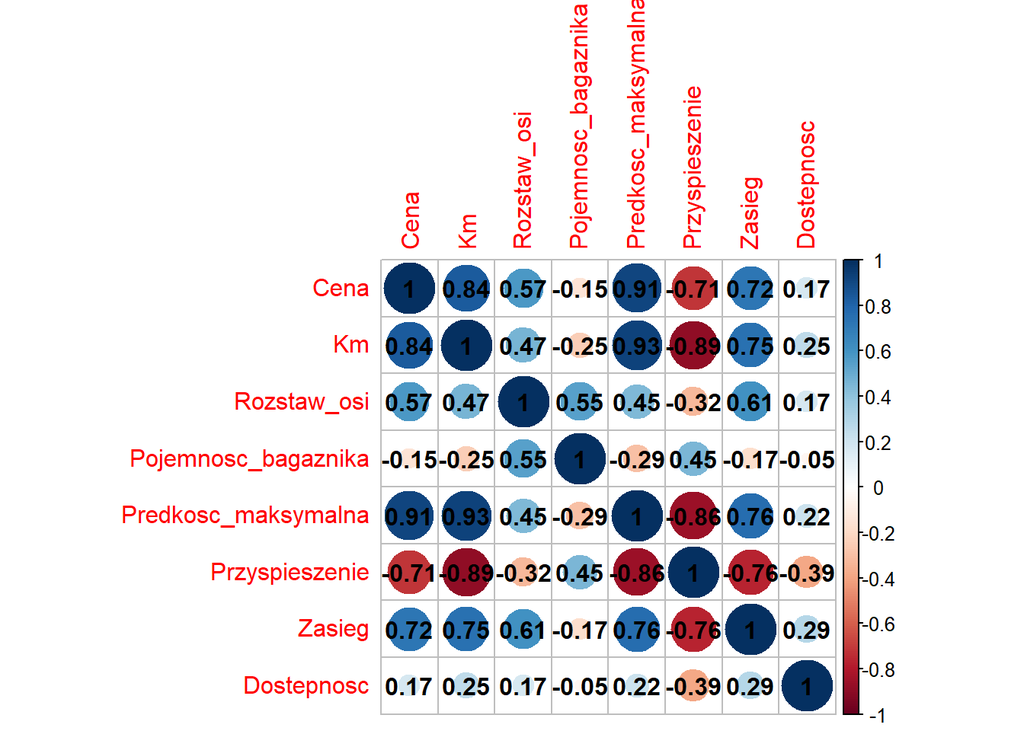

```r
corrplot(cor(Auta[,c(-1,-2)]), method="circle", addCoef.col = "black")
```

Jak można zauważyć zmienna *Prędkość maksymalna* jest wysoko skorelowana zarówno z *Ceną* jak i *Km*, więc usuwamy ją z naszego zbioru zmiennych.

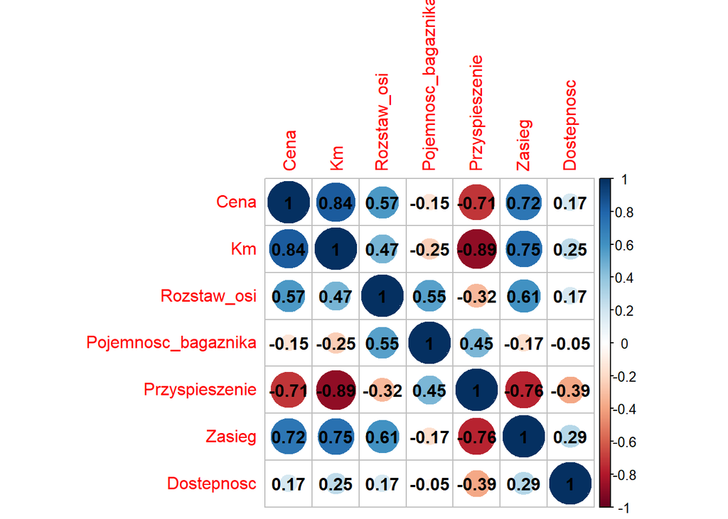

```r
corrplot(cor(Auta[,c(-1,-2,-7)]), method="circle", addCoef.col = "black")
```

```r
Auta <- Auta[,-7]
```

W kolejnym kroku wyznaczamy współczynnik zmienności, który powninien wynosić więcej niż 10%. W przeciwnym wypadku zmienna nie różnicuje znacznie obiektów.

```r
cv <- c()
auta <- as.data.frame(Auta)
for (i in 3:ncol(auta)) {
  cv[i-2] <- (sd(auta[,i])/mean(auta[,i]))*100
}

zmienna <- c("Cena","Km","Rozstaw_osi","Pojemnosc_bagaznika","Przyspieszenie","Zasieg","Dostepnosc")
wspolczynnik_zmiennosci <- data.frame(zmienna = zmienna, wspolczynnik_zmiennosci = cv)
```

```r
knitr::kable((wspolczynnik_zmiennosci), "markdown", align = "rl")
```

| zmienna | wspolczynnik_zmiennosci |
| --- | --- |
| Cena | 56.90231 |
| Km | 60.52320 |
| Rozstaw_osi | 10.52695 |
| Pojemnosc_bagaznika | 73.98408 |
| Przyspieszenie | 37.14603 |
| Zasieg | 33.08155 |
| Dostepnosc | 86.42060 |

Wszystkie zmienne spełniają założenie.

## Porządkowanie liniowe

Pierwszym krokiem w porządkowaniu liniowym jest zamiana wszystkich zmiennych na stymulany. Zamieniając destymulanty na stymulanty mnożymy dane przez -1 (w naszym przypadku mamy dwie takie zmienne *Cena* i *Przyspieszenie*)

Zamieniając nominanty (to jest *Rozstaw_osi* i *pojemnosc_bagaznika*) na stymulanty korzystamy ze wzoru:

dla $x_{ij}=N_j$ $z_{ij}=1$

dla $x_{ij}>N_j$ $z_{ij}=\frac{1}{x_{ij}-N_j+1}$

dla $x_{ij}<N_j$ $z_{ij}=\frac{1}{x_{ij}-N_j-1}$

```r
auta_stymulanty_cena <- c()
for(i in 1:nrow(auta)){
  auta_stymulanty_cena[i] = auta[i,3]*-1
}

auta_stymulanty_rozstaw_osi <- c()
for (i in 1:nrow(auta)) {
  if(auta[i,4] > 250){
    auta_stymulanty_rozstaw_osi[i] = 1/(auta[i,5]-250+1)
  }
  else if(auta[i,4] < 250){
    auta_stymulanty_rozstaw_osi[i] = -1/(auta[i,5]-250-1)
  }
  else if(auta[i,4] == 250){
    auta_stymulanty_rozstaw_osi[i] = 1
  }
}

auta_stymulanty_pojemnsc_bagaznika <- c()
for (i in 1:nrow(auta)) {
  if(auta[i,5] > 1183){
    auta_stymulanty_pojemnsc_bagaznika[i] = 1/(auta[i,6]-1183+1)
  }
  else if(auta[i,5] < 1183){
    auta_stymulanty_pojemnsc_bagaznika[i] = -1/(auta[i,6]-1183-1)
  }
  else if(auta[i,5] == 1183){
    auta_stymulanty_pojemnsc_bagaznika[i] = 1
  }
}

auta_stymulanty_przyspieszenie <- c()
for(i in 1:nrow(auta)){
  auta_stymulanty_przyspieszenie[i] = auta[i,7]*-1
}

auta_stymulanty <- data.frame(Marka = auta$Marka, Model = auta$Model, Cena = auta_stymulanty_cena, Km = auta$Km, Rozstaw_osi = auta_stymulanty_rozstaw_osi, Pojemnosc_bagaznika = auta_stymulanty_pojemnsc_bagaznika, Przyspieszenie = auta_stymulanty_przyspieszenie, Zasieg = auta$Zasieg,Dostepnosc = auta$Dostepnosc)
```

```r
knitr::kable((head(auta_stymulanty,4)), "markdown")
```

| Marka | Model | Cena | Km | Rozstaw_osi | Pojemnosc_bagaznika | Przyspieszenie | Zasieg | Dostepnosc |
| --- | --- | --- | --- | --- | --- | --- | --- | --- |
| DS3 | Crossback E-Tense | -186900 | 136 | -0.2000000 | 0.0074627 | -9.1 | 341 | 15 |
| Hyundai | Kona Electric | -175900 | 204 | -0.1111111 | 0.0142857 | -7.9 | 484 | 12 |
| Kia | e-Niro 64 kWh | -191900 | 204 | -0.0526316 | -0.0045249 | -7.8 | 455 | 18 |
| Mazda | MX-30 | -153900 | 145 | -0.0666667 | 0.0769231 | -9.7 | 200 | 15 |

Następnie przeprowadzamy standaryzację danych za pomocą funkcji scale.

```r
knitr::kable((head(auta_stand,4)), "markdown")
```

| Marka | Model | Cena | Km | Rozstaw_osi | Pojemnosc_bagaznika | Przyspieszenie | Zasieg | Dostepnosc |
| --- | --- | --- | --- | --- | --- | --- | --- | --- |
| DS3 | Crossback E-Tense | 0.6038586 | -0.8366248 | -2.4363785 | 0.1613534 | -0.4672440 | -0.6005412 | -0.2574180 |
| Hyundai | Kona Electric | 0.6717502 | -0.4288077 | -1.1243785 | 0.5267331 | -0.0506302 | 0.4152584 | -0.4373607 |
| Kia | e-Niro 64 kWh | 0.5729988 | -0.4288077 | -0.2612205 | -0.4805927 | -0.0159123 | 0.2092571 | -0.0774753 |
| Mazda | MX-30 | 0.8075333 | -0.7826490 | -0.4683784 | 3.8810240 | -0.6755509 | -1.6021339 | -0.2574180 |

Po przeprowadzeniu zamiany danych na stymulanty oraz ich standaryzacji możemy przystąpić do tworzenia rangingów za pomocą poszczególnych metod.

### Metoda Hellwiga

Pierwszy ranking budujemy wykorzystując metodę Hellwiga.

Wyznaczamy wzorzec - parametry idealnego obiektu

```r
wzorzec
```

```
## [1] 1.111194 2.365939 1.054308 3.881024 1.581107 2.034855 3.161493
```

Kolejnym etapem jest wyznaczenie odleglosci poszczególnych obiektow od wzorca.

```r
odleglosc_obiektu
```

```
##  [1] 7.704846 6.499159 6.725234 6.506423 4.468301 7.678976 6.799459 7.257873 5.604236 6.475889
## [11] 7.055935 7.910176 7.906529 6.012906 6.107748 5.580925 6.084134 6.501180 6.078676 4.979956
## [21] 8.056092 7.996932 6.865081 8.692730
```

Tworzymy odleglość “możliwie daleką”

```r
mean <- mean(odleglosc_obiektu)
sd <- sd(odleglosc_obiektu)
(d0 <- mean + 2*sd)
```

```
## [1] 8.815553
```

Wyznaczamy wartości miary dla każdego obiektu.

```r
knitr::kable(head((wartosc_miary),5), "markdown", align = "lll")
```

| Marka | Model | Wartosc |
| --- | --- | --- |
| DS3 | Crossback E-Tense | 0.1259940 |
| Hyundai | Kona Electric | 0.2627622 |
| Kia | e-Niro 64 kWh | 0.2371172 |
| Mazda | MX-30 | 0.2619382 |
| Nissan | Leaf 62 kWh | 0.4931344 |

Ostatnim etapem jest utworzenie rangingu aut elektrycznych.

```r
ranking_hellwig <- wartosc_miary[order(-wartosc_miary$Wartosc),]
knitr::kable((ranking_hellwig), "markdown", align = "lll")
```

|  | Marka | Model | Wartosc |
| --- | --- | --- | --- |
| 5 | Nissan | Leaf 62 kWh | 0.4931344 |
| 20 | Tesla | S | 0.4350943 |
| 16 | Audi | e-tron GT quattro | 0.3669229 |
| 9 | Ford | Mustang Mach-E GT | 0.3642786 |
| 14 | Skoda | Enyaq iV | 0.3179208 |
| 19 | Mercedes-Benz | EQS 350 | 0.3104601 |
| 17 | BMW | iX xDrive40 | 0.3098410 |
| 15 | Audi | Q4 e-tron | 0.3071623 |
| 10 | Porsche | Tycan 4S Sport Turismo | 0.2654019 |
| 2 | Hyundai | Kona Electric | 0.2627622 |
| 18 | BMW | i4 M50 | 0.2625330 |
| 4 | Mazda | MX-30 | 0.2619382 |
| 3 | Kia | e-Niro 64 kWh | 0.2371172 |
| 7 | Volkswagen | ID.3 | 0.2286974 |
| 23 | BMW | i7 xDrive60 | 0.2212535 |
| 11 | Mercedes-Benz | EQV | 0.1996039 |
| 8 | Volkswagen | ID.BuzzPro | 0.1766969 |
| 6 | Peugeot | e-2008 | 0.1289287 |
| 1 | DS3 | Crossback E-Tense | 0.1259940 |
| 13 | Toyota | Proace Electric Life | 0.1031160 |
| 12 | Opel | Mokka-e | 0.1027023 |
| 22 | Opel | Combo-e Life | 0.0928610 |
| 21 | Kia | e-Soul | 0.0861502 |
| 24 | Smart | EQ fortwo cabrio | 0.0139326 |

### Metoda sumy rang

W celu nadania rang poszczególnym cechom wczytujemy zestandaryzowane dane do excela

```r
# write_xlsx(auta_stand,"Auta_rangi.xlsx")

Auta_rangi <- read_excel("Auta_rangi.xlsx")
knitr::kable((head(Auta_rangi,5)), "markdown")
```

| Marka | Model | Cena | R1 | Km | R2 | Rozstaw_osi | R3 | Pojemnosc_bagaznika | R4 | Przyspieszenie | R5 | Zasieg | R6 | Dostepnosc | R7 |
| --- | --- | --- | --- | --- | --- | --- | --- | --- | --- | --- | --- | --- | --- | --- | --- |
| Smart | EQ fortwo cabrio | 1.0587320 | 23 | -1.1604796 | 1.0 | 0.7473328 | 17 | -0.1844064 | 15 | -1.717086 | 1.0 | -2.0851714 | 1 | -1.1571315 | 1 |
| BMW | i7 xDrive60 | -2.2543758 | 1 | 1.6102779 | 22.5 | 0.7192079 | 15 | -0.1599898 | 17 | 1.060340 | 19.0 | 1.4168511 | 22 | -1.0971506 | 2 |
| Toyota | Proace Electric Life | 0.7970409 | 20 | -0.8366248 | 4.5 | 0.3214111 | 14 | -0.2519556 | 14 | -1.508779 | 2.5 | -0.6786796 | 7 | -1.0371697 | 3 |
| Opel | Combo-e Life | 0.5924405 | 16 | -0.8366248 | 4.5 | -0.0115212 | 11 | -0.2951288 | 11 | -1.300472 | 4.0 | -1.0338543 | 4 | -0.9771888 | 4 |
| Volkswagen | ID.BuzzPro | 0.5125136 | 13 | -0.4288077 | 11.5 | 0.2081216 | 12 | -0.2907302 | 12 | -0.849140 | 5.0 | -0.0464687 | 12 | -0.8572270 | 5 |

Następnie dla każdego obiektu obliczamy sumy z uzyskanych rang.

```r
suma_rangi <- c()
for (i in 1:nrow(Auta_rangi)) {
  suma <- 0
  for (j in 4:ncol(Auta_rangi)){
    if (j%%2==0){
      suma <- suma + Auta_rangi[i,j]
    }
    suma_rangi[i] <- suma
  }
}
wartosc_miary <- data.frame(Marka = Auta_rangi$Marka, Model = Auta_rangi$Model)
for (i in 1:nrow(Auta_rangi)) {
  wartosc_miary[i,3] <- suma_rangi[i]
}
```

Posortowanie obiektów względem wartości uzyskanych w poprzednim kroku tworzy finalny ranking.

```r
ranking_sumy_rang <- wartosc_miary[order(-wartosc_miary$V3),]
knitr::kable((ranking_sumy_rang), "markdown", align = "lll")
```

|  | Marka | Model | V3 |
| --- | --- | --- | --- |
| 23 | Tesla | S | 137.0 |
| 11 | Porsche | Tycan 4S Sport Turismo | 113.0 |
| 22 | Audi | e-tron GT quattro | 111.0 |
| 18 | Ford | Mustang Mach-E GT | 110.5 |
| 15 | Audi | Q4 e-tron | 109.0 |
| 24 | Nissan | Leaf 62 kWh | 106.5 |
| 16 | Mercedes-Benz | EQS 350 | 104.0 |
| 9 | BMW | i4 M50 | 103.5 |
| 20 | Skoda | Enyaq iV | 101.0 |
| 21 | BMW | iX xDrive40 | 100.5 |
| 2 | BMW | i7 xDrive60 | 98.5 |
| 10 | Hyundai | Kona Electric | 92.5 |
| 12 | Mazda | MX-30 | 80.0 |
| 17 | Volkswagen | ID.3 | 79.5 |
| 14 | Kia | e-Niro 64 kWh | 78.0 |
| 19 | Mercedes-Benz | EQV | 76.0 |
| 13 | DS3 | Crossback E-Tense | 71.5 |
| 5 | Volkswagen | ID.BuzzPro | 70.5 |
| 7 | Opel | Mokka-e | 68.5 |
| 3 | Toyota | Proace Electric Life | 65.0 |
| 8 | Peugeot | e-2008 | 62.0 |
| 1 | Smart | EQ fortwo cabrio | 59.0 |
| 4 | Opel | Combo-e Life | 54.5 |
| 6 | Kia | e-Soul | 48.5 |

### Metoda Standaryzowanych Sum

Ostatnią wykorzystywaną przez nas metodą jest metoda standaryzowanych sum.

Rozpoczynamy od budowania syntetycznej miary, czyli zsumowania oszacowań uzyskanych w ramach obiektów.

```r
suma_oszacowan <- c()
for (i in 1:nrow(auta_stand)) {
  suma <- 0
  for (j in 3:ncol(auta_stand)){
    suma <- suma + auta_stand[i,j]
  }
  suma_oszacowan[i] <- suma/7
}
```

Następnie standaryzujemy oraz sortujemy uzyskane wartości, tworząc w ten sposób ranking.

```r
min <- min(suma_oszacowan)
max <- max(suma_oszacowan-min)
suma_oszacowan_standaryzacja <- c()

for (i in 1:length(suma_oszacowan)) {
  suma_oszacowan_standaryzacja[i] <- (suma_oszacowan[i]-min)/max
}

wartosc_miary <- data.frame(Marka = Auta$Marka, Model = Auta$Model, Oszacowanie = suma_oszacowan_standaryzacja)
ranking_sum <- wartosc_miary[order(-wartosc_miary$Oszacowanie),]
knitr::kable((ranking_sum), "markdown", align = "lll")
```

|  | Marka | Model | Oszacowanie |
| --- | --- | --- | --- |
| 20 | Tesla | S | 1.0000000 |
| 5 | Nissan | Leaf 62 kWh | 0.8805632 |
| 9 | Ford | Mustang Mach-E GT | 0.7731971 |
| 16 | Audi | e-tron GT quattro | 0.7221871 |
| 19 | Mercedes-Benz | EQS 350 | 0.6168157 |
| 18 | BMW | i4 M50 | 0.6122054 |
| 15 | Audi | Q4 e-tron | 0.6117762 |
| 10 | Porsche | Tycan 4S Sport Turismo | 0.5734734 |
| 23 | BMW | i7 xDrive60 | 0.5313100 |
| 17 | BMW | iX xDrive40 | 0.5228373 |
| 14 | Skoda | Enyaq iV | 0.5193121 |
| 4 | Mazda | MX-30 | 0.4952924 |
| 7 | Volkswagen | ID.3 | 0.3820767 |
| 2 | Hyundai | Kona Electric | 0.3733307 |
| 3 | Kia | e-Niro 64 kWh | 0.3683493 |
| 8 | Volkswagen | ID.BuzzPro | 0.2518789 |
| 11 | Mercedes-Benz | EQV | 0.2242795 |
| 6 | Peugeot | e-2008 | 0.1453924 |
| 13 | Toyota | Proace Electric Life | 0.1195397 |
| 1 | DS3 | Crossback E-Tense | 0.0610069 |
| 22 | Opel | Combo-e Life | 0.0583148 |
| 12 | Opel | Mokka-e | 0.0291694 |
| 21 | Kia | e-Soul | 0.0284316 |
| 24 | Smart | EQ fortwo cabrio | 0.0000000 |

Zestawiamy wszystkie obliczone powyżej rankingi.

```r
knitr::kable(data.frame(Hellwig = paste(ranking_hellwig$Marka,ranking_hellwig$Model), Sumy_rang = paste(ranking_sumy_rang$Marka,ranking_sumy_rang$Model),Standaryzowanych_sum = paste(ranking_sum$Marka,ranking_sum$Model)), format="markdown",align = "lll")
```

| Hellwig | Sumy_rang | Standaryzowanych_sum |
| --- | --- | --- |
| Nissan Leaf 62 kWh | Tesla S | Tesla S |
| Tesla S | Porsche Tycan 4S Sport Turismo | Nissan Leaf 62 kWh |
| Audi e-tron GT quattro | Audi e-tron GT quattro | Ford Mustang Mach-E GT |
| Ford Mustang Mach-E GT | Ford Mustang Mach-E GT | Audi e-tron GT quattro |
| Skoda Enyaq iV | Audi Q4 e-tron | Mercedes-Benz EQS 350 |
| Mercedes-Benz EQS 350 | Nissan Leaf 62 kWh | BMW i4 M50 |
| BMW iX xDrive40 | Mercedes-Benz EQS 350 | Audi Q4 e-tron |
| Audi Q4 e-tron | BMW i4 M50 | Porsche Tycan 4S Sport Turismo |
| Porsche Tycan 4S Sport Turismo | Skoda Enyaq iV | BMW i7 xDrive60 |
| Hyundai Kona Electric | BMW iX xDrive40 | BMW iX xDrive40 |
| BMW i4 M50 | BMW i7 xDrive60 | Skoda Enyaq iV |
| Mazda MX-30 | Hyundai Kona Electric | Mazda MX-30 |
| Kia e-Niro 64 kWh | Mazda MX-30 | Volkswagen ID.3 |
| Volkswagen ID.3 | Volkswagen ID.3 | Hyundai Kona Electric |
| BMW i7 xDrive60 | Kia e-Niro 64 kWh | Kia e-Niro 64 kWh |
| Mercedes-Benz EQV | Mercedes-Benz EQV | Volkswagen ID.BuzzPro |
| Volkswagen ID.BuzzPro | DS3 Crossback E-Tense | Mercedes-Benz EQV |
| Peugeot e-2008 | Volkswagen ID.BuzzPro | Peugeot e-2008 |
| DS3 Crossback E-Tense | Opel Mokka-e | Toyota Proace Electric Life |
| Toyota Proace Electric Life | Toyota Proace Electric Life | DS3 Crossback E-Tense |
| Opel Mokka-e | Peugeot e-2008 | Opel Combo-e Life |
| Opel Combo-e Life | Smart EQ fortwo cabrio | Opel Mokka-e |
| Kia e-Soul | Opel Combo-e Life | Kia e-Soul |
| Smart EQ fortwo cabrio | Kia e-Soul | Smart EQ fortwo cabrio |

Rankingi różnią się między sobą jednak, za każdym razem w najlepszej grupie znajdują się: Tesla S, Audi e-tron, Nissan Leaf oraz Ford Mustang Mach-E. Nikt nie powinien być zaskoczony wysoką pozycją Tesli, ponieważ jest ona pionierem wśród aut elektrycznych. Nissan znalazł się w tej grupie, dzięki dostępności, która jest największa wśród rozpatrywanych aut, ma on też stosunkowo niską cenę jak na auto z takimi parametrami.

Najgorszymi autami ze danego zbioru okazały się: Opel Combo-e, Kia e-Soul oraz Smart EQ. Jednym z powodów jest mała ilość koni mechanicznych, co przekłada się na długi czas w jakim auta osiągają 100km/h. Dodatkowo Smart w dniu zbierania danych nie był dostępny w sprzedaży na serwisie OtoMoto, co mocno działa na jego niekorzyść.

Największym zaskoczeniem dla nas był dość niskie miejsce w rankingu marki BMW, ponieważ cechuje je dobre przyśpieszenie i daleki zasięg. Jest to jednak jedna z najdroższych marek na Polskim rynku.

## Analiza skupień

Kolejną częścią projektu jest przeprowadzenie analizy skupień.

Wykorzystujemy do tego zestandaryzowane dane.

```r
auta_standaryzacja_cena <- c()
auta_standaryzacja_cena <- scale(Auta$Cena)

auta_standaryzacja_km <- c()
auta_standaryzacja_km <- scale(Auta$Km)

auta_standaryzacja_rozstaw_osi <- c()
auta_standaryzacja_rozstaw_osi <- scale(Auta$Rozstaw_osi)

auta_standaryzacja_pojemnosc_bagaznika <- c()
auta_standaryzacja_pojemnosc_bagaznika <- scale(Auta$Pojemnosc_bagaznika)

auta_standaryzacja_przyspieszenie <- c()
auta_standaryzacja_przyspieszenie <- scale(Auta$Przyspieszenie)

auta_standaryzacja_zasieg <- c()
auta_standaryzacja_zasieg <- scale(Auta$Zasieg)

auta_standaryzacja_dostepnosc <- c()
auta_standaryzacja_dostepnosc <- scale(Auta$Dostepnosc)

auta_standaryzacja <- data.frame(Marka = Auta$Marka, Model = Auta$Model, Cena = auta_standaryzacja_cena, Km = auta_standaryzacja_km, Rozstaw_osi = auta_standaryzacja_rozstaw_osi, Pojemnosc_bagaznika = auta_standaryzacja_pojemnosc_bagaznika, Przyspieszenie = auta_standaryzacja_przyspieszenie, Zasieg = auta_standaryzacja_zasieg, Dostepnosc = auta_standaryzacja_dostepnosc)
```

### Grupowanie hierarchiczne

We wstępnej analizie danych na wykresach pudełkowych z wąsem, można zauważyć, że mamy wartości odstające. Dlatego przed przystąpieniem do analizy skupień usuwamy je, wykorzystując regułę trzech sigm.

```r
numer_wiersza <- c()
for (i in 1:nrow(auta_standaryzacja)){
  for (j in 3:ncol(auta_standaryzacja)) {
    if (abs(auta_standaryzacja[i,j])>3){
      numer_wiersza[i] <- i
    }
  }
}
numer_wiersza <- numer_wiersza[!is.na(numer_wiersza)]
auta <- auta_standaryzacja[-numer_wiersza,]
```

Wyznaczamy macierz odległości pomiędzy obiektami, wykorzystując odległość euklidesową.

```r
d <- dist(x = auta, method = "euclidean")
```

Wykonujemy grupowanie hierarchiczne za pomocą wybranych metod.

#### Metoda najbliższego sąsiąda

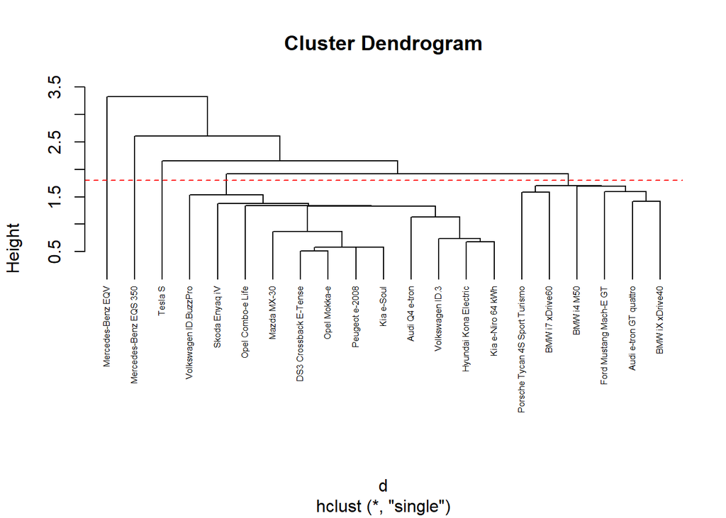

```r
single <- hclust(d, method = "single")
{plot(single, hang = -1, cex = 0.5, labels = paste(auta[,1],auta[,2]))
abline(h=1.8,lty=2,col="red")}
```

#### Metoda najdalszego sąsiada

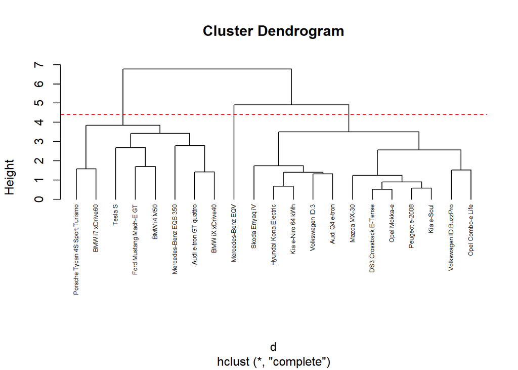

```r
complete <- hclust(d, method = "complete")
{plot(complete, hang = -1, cex = 0.5, labels = paste(auta[,1],auta[,2]))
abline(h=4.4,lty=2,col="red")}
```

#### Metoda Warda

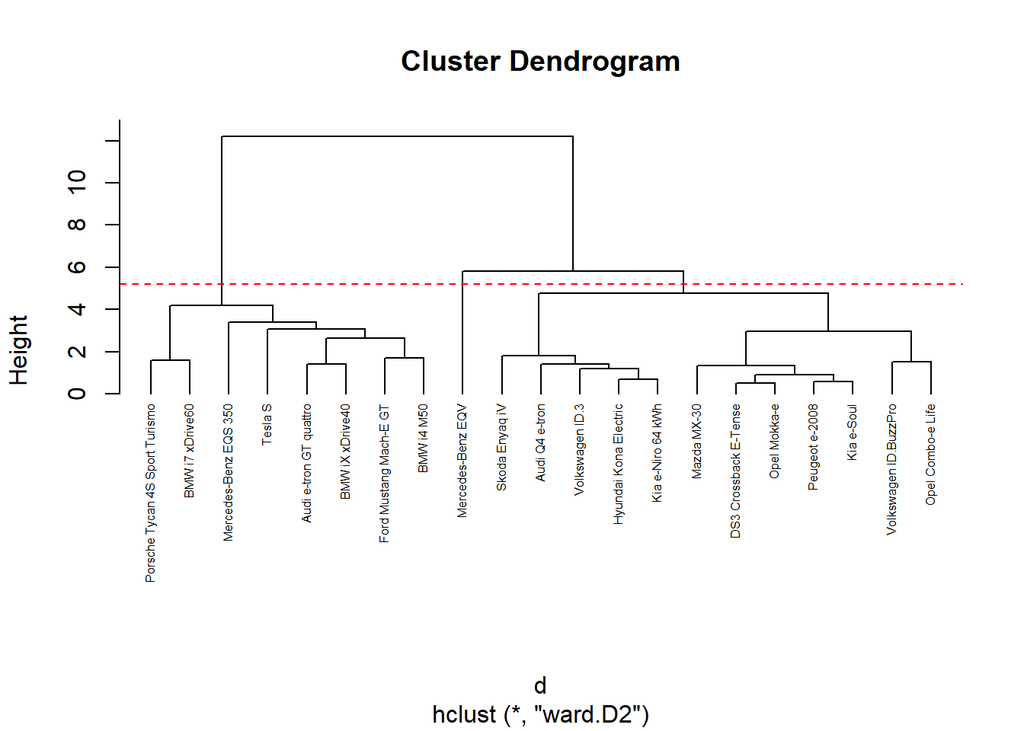

```r
ward.D2 <- hclust(d, method = "ward.D2")
{plot(ward.D2, hang = -1, cex = 0.5, labels = paste(auta[,1],auta[,2]))
abline(h=5.2,lty=2,col="red")}
```

Analizując powyższe dendogramy, wydaje się, że optymalnym podziałem jest podział na trzy grupy.

### Grupowanie podziałowe

#### Metoda k-srednich

Metoda profilu

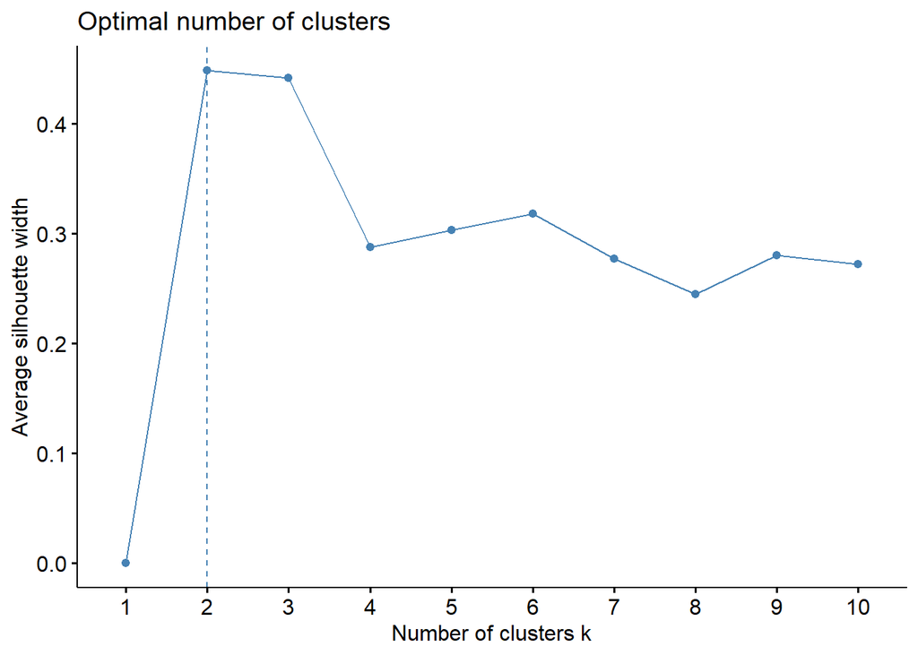

```r
fviz_nbclust(auta[,-c(1,2)],kmeans, method = "silhouette")
```

Metoda łokcia

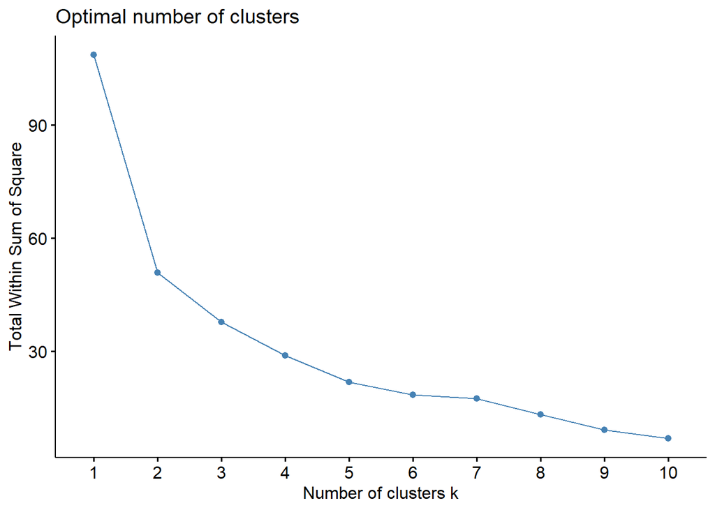

```r
fviz_nbclust(auta[,-c(1,2)],kmeans, method = "wss")
```

Kierując się metodą łokcia oraz profilu powinnyśmy podzielić dane na dwie grupy.

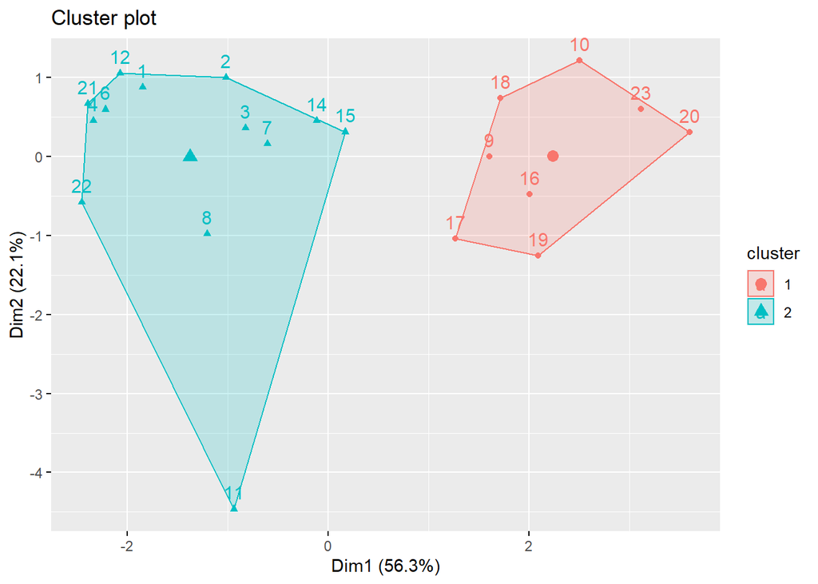

```r
km <- kmeans(x = auta[,-c(1,2)], centers = 2, nstart = 20)
fviz_cluster(km,auta[,-c(1,2)])
```

Na wykresie można jednak zauważyć, że obserwacja 11 znacząco odstaje od pozostałych obiektów w grupie, dlatego podział na 3 grupy wydaje się być bardziej uzasadniony.

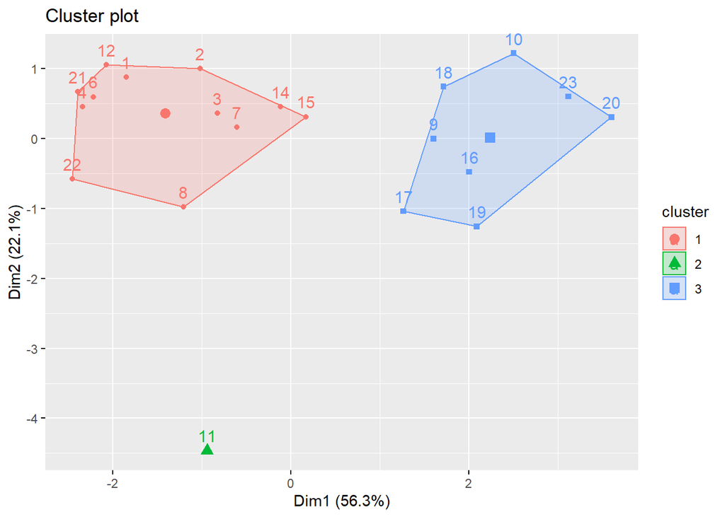

```r
km <- kmeans(x = auta[,-c(1,2)], centers = 3, nstart = 20)
fviz_cluster(km,auta[,-c(1,2)])
```

#### Metoda k-medoid

Metoda profilu

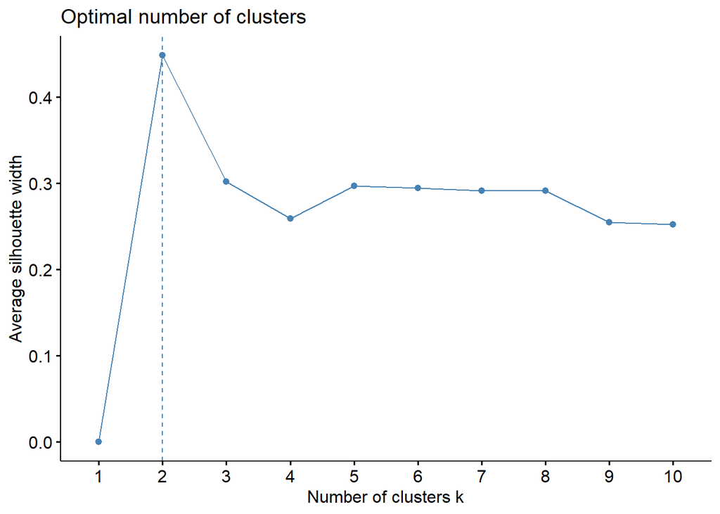

```r
fviz_nbclust(auta[,-c(1,2)],pam, method = "silhouette")
```

Metoda łokcia

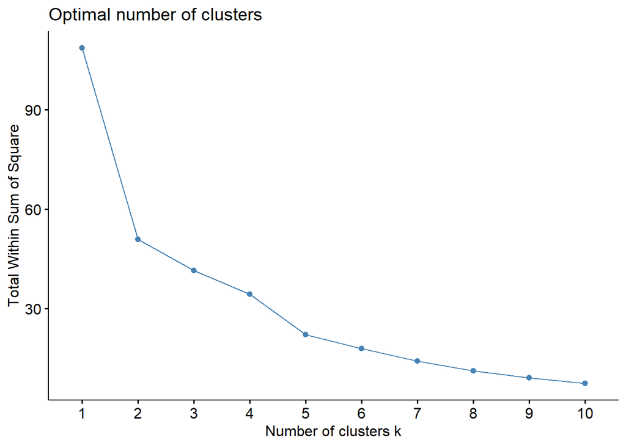

```r
fviz_nbclust(auta[,-c(1,2)],pam, method = "wss")
```

Zgodnie z metodą profilu optymalny jest podział na 2 grupy, natomiast metoda łokcia wskazuje na 2 lub 5 grup. Zwizualizujmy zatem podział na 5 grup.

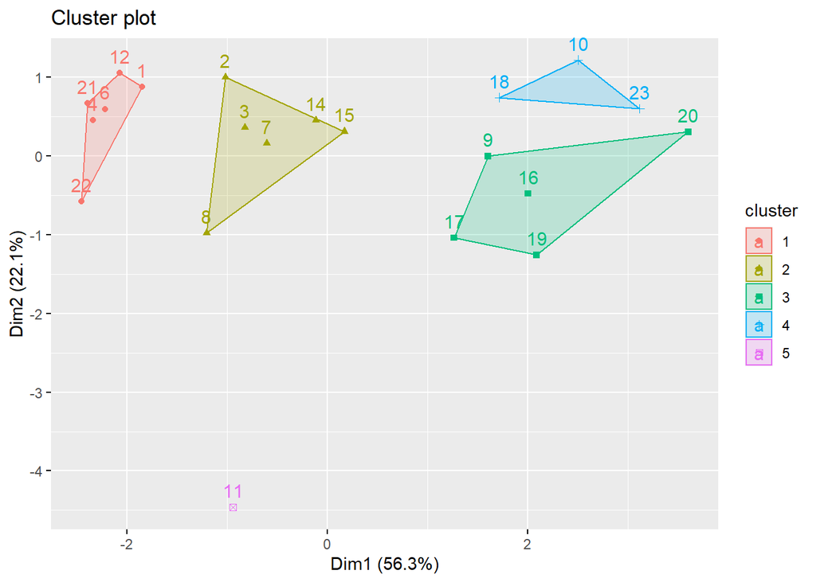

```r
p <- pam(x = auta[,-c(1,2)], k = 5, metric = "euclidean")
fviz_cluster(p,auta[,-c(1,2)])
```

Uwzględniając metody z grupowania hierarchicznego i podziałowego postanowiłyśmy podzielić dane na 3 grupy.